# NOAA Storm Damage Analysis

Jeremiah Schwab

August 23, 2015

```r
library(reshape2)
```

## Data Processing

The NOAA Storm Data can be downloaded from the following URL: https://d396qusza40orc.cloudfront.net/repdata%2Fdata%2FStormData.csv.bz2

This compressed file can be read directly using read.csv:

```r
raw_data <- read.csv("repdata-data-StormData.csv.bz2")
```

We want to format the BGN_DATE field accordingly so we can isolate the year as its own field.

```r
raw_data$BGN_DATE <- as.Date(raw_data$BGN_DATE, "%m/%d/%Y")
raw_data$YEAR <- format(raw_data$BGN_DATE, "%Y")
```

We are only interested in several fields: YEAR, EVTYPE (Storm Event), FATALITIES, INJURIES, PROPDMG (Property Damage), PROPDMGEXP (Establshises the Units for PROPDMG), CROPDMG (Crop Damage), and CROPDMGEXP (Establishes the Units for CROPDMG). We are also only interested in the data from 2000 and after as it is the most relevant. And we will shed some of the excess factors by dropping the levels.

```r
processed_data <- raw_data[,c("YEAR","EVTYPE","FATALITIES","INJURIES","PROPDMG","PROPDMGEXP","CROPDMG","CROPDMGEXP")]
recent_data <- processed_data[processed_data$YEAR > 1999,]
recent_data <- droplevels(recent_data)
```

Now we want to establish a uniform dollar amount for Property and Crop Damage by multiplying accordingly based on the PROPDMGEXP and CROPDMGEXP.

```r
recent_data$PROPDMG <- ifelse(recent_data$PROPDMGEXP == "K",
  recent_data$PROPDMG * 1000,ifelse(recent_data$PROPDMGEXP == "M",
    recent_data$PROPDMG * 1000000,ifelse(recent_data$PROPDMGEXP == "B",
      recent_data$PROPDMG * 1000000000,recent_data$PROPDMG)))
recent_data$CROPDMG <- ifelse(recent_data$CROPDMGEXP == "K",
  recent_data$CROPDMG * 1000,ifelse(recent_data$CROPDMGEXP == "M",
    recent_data$CROPDMG * 1000000,ifelse(recent_data$CROPDMGEXP == "B",
      recent_data$CROPDMG * 1000000000,recent_data$CROPDMG)))
recent_data$ECONOMIC <- recent_data$PROPDMG + recent_data$CROPDMG
```

Now we want to melt and cast Fatalities, Injuries, and the Economic Cost based on the Event Type.

```r
melted_data <- melt(recent_data, id="EVTYPE", measure = c("FATALITIES", "INJURIES", "ECONOMIC"))
casted_data <- dcast(melted_data, EVTYPE ~ variable, sum)
```

By ordering each variable in descending order, we can pull the top 3 Storm Events that cause the most Fatalities, Injuries, and Economic Cost. Economic cost is divided by a Billion for easier reading of the data.

```r
casted_data <- casted_data[order(casted_data$FATALITIES, decreasing = TRUE), ]
top_fata_data <- casted_data[1:3,]
top_fata_data <- droplevels(top_fata_data)
casted_data <- casted_data[order(casted_data$INJURIES, decreasing = TRUE), ]
top_inju_data <- casted_data[1:3,]
top_inju_data <- droplevels(top_inju_data)
casted_data <- casted_data[order(casted_data$ECONOMIC, decreasing = TRUE), ]
casted_data$ECONOMIC <- casted_data$ECONOMIC / 1000000000
top_econ_data <- casted_data[1:3,]
top_econ_data <- droplevels(top_econ_data)
```

## Results

We can now graph the data to help gain a visual understanding of the damages that have occurred.

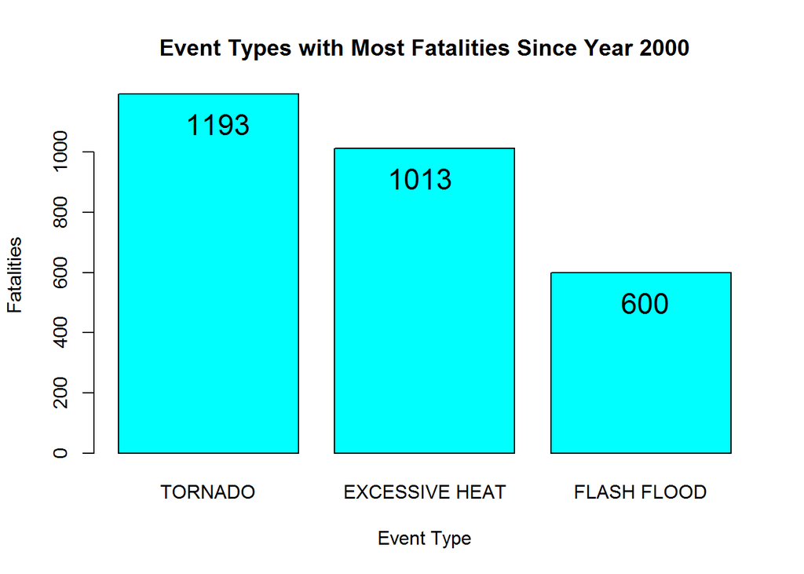

```r
barplot(top_fata_data$FATALITIES,names.arg = top_fata_data$EVTYPE,col = "cyan",xlab = "Event Type", ylab = "Fatalities", main = "Event Types with Most Fatalities Since Year 2000")
text(c(0.75,1.875,3.125), top_fata_data$FATALITIES-100, top_fata_data$FATALITIES, cex=1.5, col = "black")
```

Here we can see that Tornados have caused the most fatalities, 1193 deaths since 2000. Excessive Heat follows closely behind at 1013, with Flash Floods coming in third at 600.

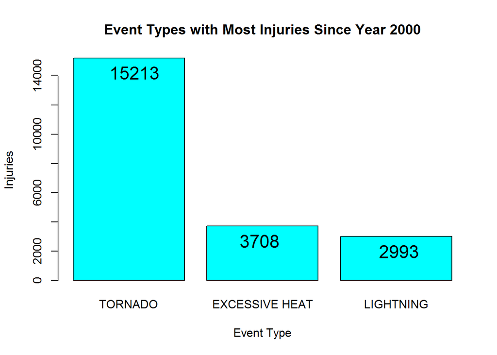

```r
barplot(top_inju_data$INJURIES,names.arg = top_inju_data$EVTYPE,col = "cyan",xlab = "Event Type", ylab = "Injuries", main = "Event Types with Most Injuries Since Year 2000")
text(c(0.75,1.875,3.125), top_inju_data$INJURIES-1000, top_inju_data$INJURIES, cex=1.5, col = "black")
```

Tornados, again, caused the most injuries at 15213. Excessive Heat and Lightning trail far behind with 3708 and 2993 injuries respectively.

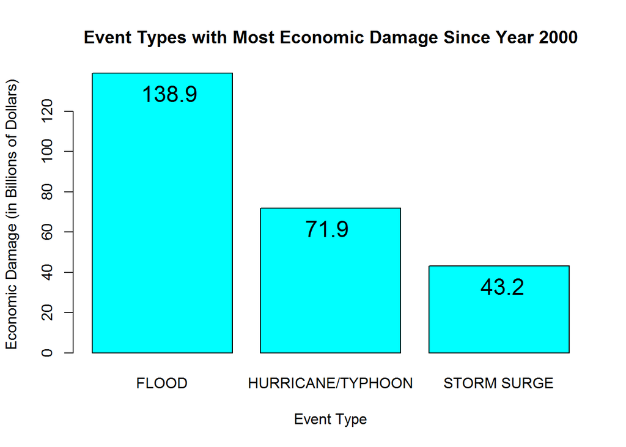

```r
barplot(top_econ_data$ECONOMIC,names.arg = top_econ_data$EVTYPE,col = "cyan",xlab = "Event Type", ylab = "Economic Damage (in Billions of Dollars)", main = "Event Types with Most Economic Damage Since Year 2000")
text(c(0.75,1.875,3.125), top_econ_data$ECONOMIC-10, round(top_econ_data$ECONOMIC,1), cex=1.5, col = "black")
```